# Métodos Computacionais II

2018/2

[Jony Arrais Pinto Junior](http://lattes.cnpq.br/4940428746026448)

## 1 - Conteúdo Aula 15

- Teste de aderência, homogeneidade e independência.

## 2 - Teste de aderência

Testar a adequabilidade de um modelo teórico.

Exemplo: Genética - Equilíbrio de Hardy-Weinberg

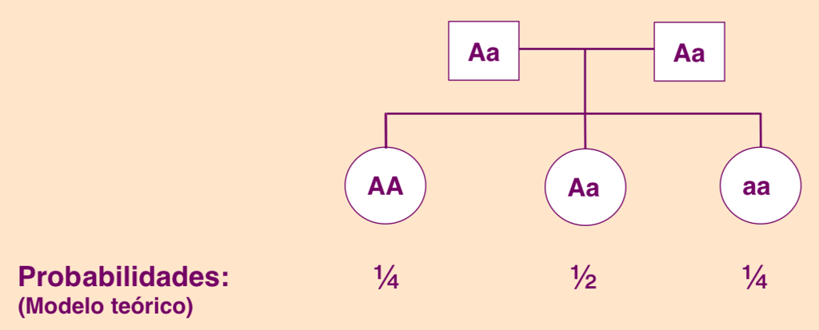

Suponha que uma amostra de tamanho 100 de uma determinada população foi avaliada e armazenada no arquivo Genotipo.csv.

Pergunta: Pode-se dizer com base na amostra observada que a população em questão segue o modelo de Hardy-Weinberg?

Hipóteses:
$$H_0: p_1 = p_{01}, \ldots, p_k = p_{0k} \times H_1: \mbox{Existe pelo menos uma diferença},$$

Estatística de teste

$$\chi^2_{obs} = \sum_{i=1}^{k}\frac{(O_i - E_i)^2}{E_i} \sim \chi^2_{k-1}.$$

Dados:

```
## # A tibble: 3 x 3
##   genotipo freq.observada freq.esperada
##   <chr>             <int>         <dbl>
## 1 aa                   29            25
## 2 Aa                   45            50
## 3 AA                   26            25
```

```r
chisq.test(table(base$genotipo),p=c(0.25,0.50,0.25), correct = FALSE)
```

```
##
##  Chi-squared test for given probabilities
##
## data:  table(base$genotipo)
## X-squared = 1.18, df = 2, p-value = 0.5543
```

```r
teste = chisq.test(table(base$genotipo),p=c(0.25,0.50,0.25), correct = FALSE)

names(teste)
```

```
## [1] "statistic" "parameter" "p.value"   "method"    "data.name" "observed"
## [7] "expected"  "residuals" "stdres"
```

## 3 - Teste de independência

Verificar se existe independência entre duas variáveis medidas nas mesmas unidades experimentais.

Exemplo: Suponha que um inspetor de qualidade toma uma amostra de 220 artigos num centro de distribuição. Se sabe que cada produto pode vir de uma de três fábricas e pode ou não estar defeituoso. O inspetor avalia todos os produtos e obtém os seguintes resultados:

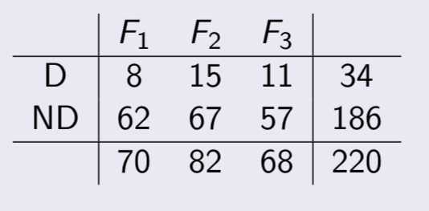

Hipóteses:
$$H_0: p_{ij} = p_{i.}p{.j}, \forall i,j \times H_1: \mbox{Existe pelo menos uma diferença},$$

$$\chi^2_{obs} = \sum_{i=1}^{r} \sum_{j=s}^{k} \frac{(O_{ij} - E_{ij})^2}{E_{ij}} \sim \chi^2_{(r-1)\times(s-1)}.$$

```r
tabela = matrix(c(8,62,15,67,11,57),nrow=2,3)
tabela
```

```
##      [,1] [,2] [,3]
## [1,]    8   15   11
## [2,]   62   67   57
```

```r
chisq.test(tabela, correct = FALSE)
```

```
##
##  Pearson's Chi-squared test
##
## data:  tabela
## X-squared = 1.401, df = 2, p-value = 0.4963
```

## 4 - Teste de homogeneidade

Verificar se uma variável aleatória se comporta de forma similar, ou homogênea em várias subpopulações.

Exemplo: Suponha que o inspetor do exemplo anterior resolveu repetir o experimento, mas desta vez, ao invés de tomar 220 artigos ao acaso, resolveu colher uma amostra de exatamente 80 artigos selecionados ao acaso dentro de cada uma das três fábricas. Os dados colhidos foram::

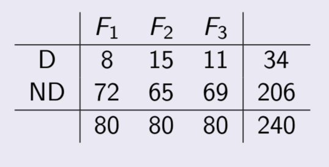

Hipóteses:
$$H_0: p_{1} = p_{2} = p_{k}, \forall i,j \times H_1: \mbox{Existe pelo menos uma diferença},$$

$$\chi^2_{obs} = \sum_{i=1}^{r} \sum_{j=s}^{k} \frac{(O_{ij} - E_{ij})^2}{E_{ij}} \sim \chi^2_{(r-1)\times(s-1)}.$$

```r
tabela2 = matrix(c(8,72,15,65,11,69),nrow=2,3)
tabela2
```

```
##      [,1] [,2] [,3]
## [1,]    8   15   11
## [2,]   72   65   69
```

```r
chisq.test(tabela2, correct = FALSE)
```

```
##
##  Pearson's Chi-squared test
##
## data:  tabela2
## X-squared = 2.5357, df = 2, p-value = 0.2814
```